# Data Understanding & Exploration

# Clustering

```
first we need to normalize the data
```

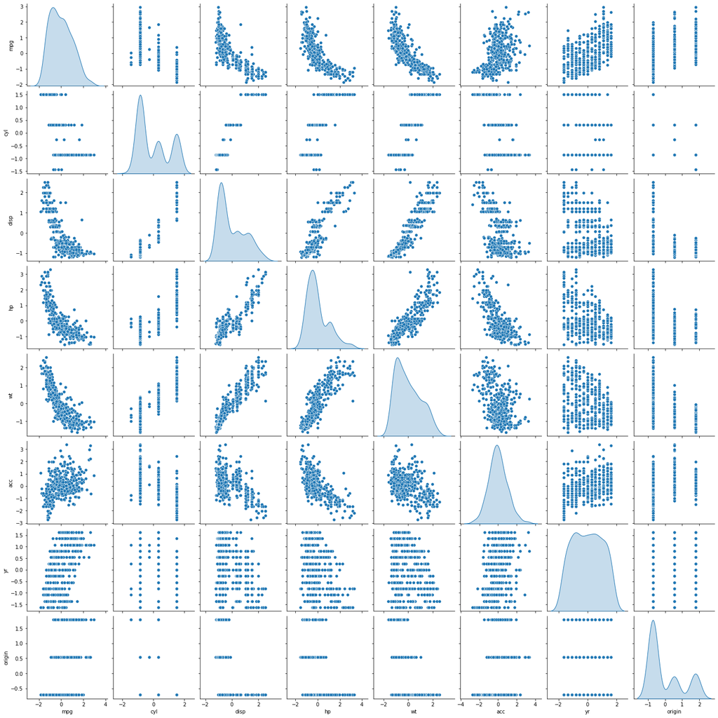

```python
# Apply K-Means clustering for 2 to 10 clusters.
print("first we need to normalize the data")
df_cluster=df.iloc[:,1:]
df_cluster=df_cluster.apply(zscore)
sns.pairplot(df_cluster,diag_kind='kde')
```

```python
clusters=range(2,10)
meanDistortions=[]

for k in clusters:
    model=KMeans(n_clusters=k)
    model.fit(df_cluster)
    prediction=model.predict(df_cluster)
    meanDistortions.append(sum(np.min(cdist(df_cluster, model.cluster_centers_, 'euclidean'), axis=1)) / df_cluster.shape[0])
```

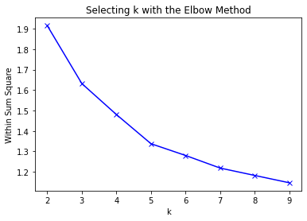

```python
# Plot a visual and find elbow point
plt.plot(clusters, meanDistortions, 'bx-')
plt.xlabel('k')
plt.ylabel('Within Sum Square')
plt.title('Selecting k with the Elbow Method')
```

```python
# On the above visual, highlight which are the possible Elbow points
elbow_index = np.where(np.array(meanDistortions) < 1.4)[0]
elbow_index = list(elbow_index)
elbow_index
```

```
[3, 4, 5, 6, 7]
```

```python
meanDistortions_elbow = list(map(lambda y: meanDistortions[y], elbow_index))
clusters_elbow = list(map(lambda y: clusters[y], elbow_index))
```

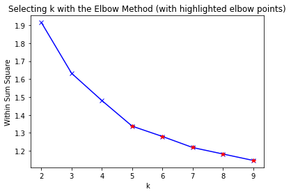

```python
plt.plot(clusters, meanDistortions, 'bx-')
plt.plot(clusters_elbow,meanDistortions_elbow, 'r*')
plt.xlabel('k')
plt.ylabel('Within Sum Square')
plt.title('Selecting k with the Elbow Method (with highlighted elbow points)')
```

```python
# Train a K-means clustering model once again on the optimal number of clusters
model=KMeans(n_clusters=5)
model.fit(df_cluster)
```

```
KMeans(n_clusters=5)
```

```python
# Add a new feature in the DataFrame which will have labels based upon cluster value
prediction=model.predict(df_cluster)
df["GROUP"] = prediction
df_cluster["GROUP"] = prediction
df.head(5)
```

|  | car_name | mpg | cyl | disp | hp | wt | acc | yr | origin | GROUP |
| --- | --- | --- | --- | --- | --- | --- | --- | --- | --- | --- |
| 0 | chevrolet chevelle malibu | 18.0 | 8 | 307.0 | 130.0 | 3504 | 12.0 | 70 | 1 | 0 |
| 1 | buick skylark 320 | 15.0 | 8 | 350.0 | 165.0 | 3693 | 11.5 | 70 | 1 | 0 |
| 2 | plymouth satellite | 18.0 | 8 | 318.0 | 150.0 | 3436 | 11.0 | 70 | 1 | 0 |
| 3 | amc rebel sst | 16.0 | 8 | 304.0 | 150.0 | 3433 | 12.0 | 70 | 1 | 0 |
| 4 | ford torino | 17.0 | 8 | 302.0 | 140.0 | 3449 | 10.5 | 70 | 1 | 0 |

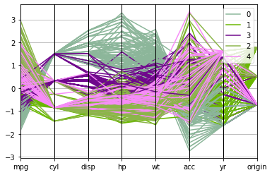

```python
# Plot a visual and color the datapoints based upon clusters
pd.plotting.parallel_coordinates(df_cluster, 'GROUP')
```

[output not shown]

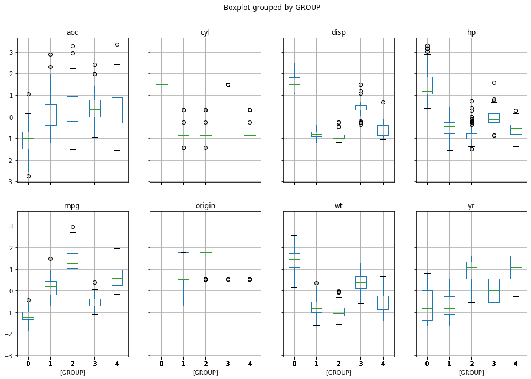

```python
df_cluster.boxplot(by='GROUP',layout = (2,4),figsize=(15,10))
```

```python
# Pass a new DataPoint and predict which cluster it belongs to.
data = [{'mpg': 23.5, 'cyl': 5, 'disp': 118, 'hp': 69, 'wt': 2100, 'acc': 12, 'yr': 81, 'origin': 2}]
df_new = pd.DataFrame(data)
```

```python
def standarization(df_new,df_orginal):
    for i in df_new.columns:
        if(df[i].max()>=df_new[i].max() and df[i].min()<=df_new[i].min() ):
            df_new[i] = (df_new[i] - df[i].mean())/df[i].std(ddof=0)
        else:
            print("We got a new max/min value so revise the model")
```

```python
standarization(df_new,df)
model.predict(df_new)
```

```
array([4], dtype=int32)
```

Our new DataPoint belongs to cluster number 4

# Data Understanding & Cleaning

```python
##libiary##

import pandas as pd
import numpy as np
from sklearn.impute import SimpleImputer
import seaborn as sns
from scipy.stats import zscore
from sklearn.cluster import KMeans
from scipy.spatial.distance import cdist
import matplotlib.pylab as plt
from sklearn.preprocessing import StandardScaler
from sklearn import svm
from sklearn import metrics
from sklearn.decomposition import PCA
from sklearn.model_selection import GridSearchCV
```

```python
df = pd.read_csv("vehicle.csv")
print(df.shape)
df.head(5)
```

```
(846, 19)
```

|  | compactness | circularity | distance_circularity | radius_ratio | pr.axis_aspect_ratio | max.length_aspect_ratio | scatter_ratio | elongatedness | pr.axis_rectangularity | max.length_rectangularity | scaled_variance | scaled_variance.1 | scaled_radius_of_gyration | scaled_radius_of_gyration.1 | skewness_about | skewness_about.1 | skewness_about.2 | hollows_ratio | class |
| --- | --- | --- | --- | --- | --- | --- | --- | --- | --- | --- | --- | --- | --- | --- | --- | --- | --- | --- | --- |
| 0 | 95 | 48.0 | 83.0 | 178.0 | 72.0 | 10 | 162.0 | 42.0 | 20.0 | 159 | 176.0 | 379.0 | 184.0 | 70.0 | 6.0 | 16.0 | 187.0 | 197 | van |
| 1 | 91 | 41.0 | 84.0 | 141.0 | 57.0 | 9 | 149.0 | 45.0 | 19.0 | 143 | 170.0 | 330.0 | 158.0 | 72.0 | 9.0 | 14.0 | 189.0 | 199 | van |
| 2 | 104 | 50.0 | 106.0 | 209.0 | 66.0 | 10 | 207.0 | 32.0 | 23.0 | 158 | 223.0 | 635.0 | 220.0 | 73.0 | 14.0 | 9.0 | 188.0 | 196 | car |
| 3 | 93 | 41.0 | 82.0 | 159.0 | 63.0 | 9 | 144.0 | 46.0 | 19.0 | 143 | 160.0 | 309.0 | 127.0 | 63.0 | 6.0 | 10.0 | 199.0 | 207 | van |
| 4 | 85 | 44.0 | 70.0 | 205.0 | 103.0 | 52 | 149.0 | 45.0 | 19.0 | 144 | 241.0 | 325.0 | 188.0 | 127.0 | 9.0 | 11.0 | 180.0 | 183 | bus |

```python
df.isnull().sum()
```

```
compactness                    0
circularity                    5
distance_circularity           4
radius_ratio                   6
pr.axis_aspect_ratio           2
max.length_aspect_ratio        0
scatter_ratio                  1
elongatedness                  1
pr.axis_rectangularity         3
max.length_rectangularity      0
scaled_variance                3
scaled_variance.1              2
scaled_radius_of_gyration      2
scaled_radius_of_gyration.1    4
skewness_about                 6
skewness_about.1               1
skewness_about.2               1
hollows_ratio                  0
class                          0
dtype: int64
```

```python
medianFiller = lambda x: x.fillna(x.median())
df.iloc[:,:18] = df.iloc[:,:18].apply(medianFiller,axis=0)
```

```python
df.isna().sum()
```

```
compactness                    0
circularity                    0
distance_circularity           0
radius_ratio                   0
pr.axis_aspect_ratio           0
max.length_aspect_ratio        0
scatter_ratio                  0
elongatedness                  0
pr.axis_rectangularity         0
max.length_rectangularity      0
scaled_variance                0
scaled_variance.1              0
scaled_radius_of_gyration      0
scaled_radius_of_gyration.1    0
skewness_about                 0
skewness_about.1               0
skewness_about.2               0
hollows_ratio                  0
class                          0
dtype: int64
```

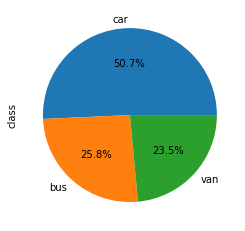

```python
df['class'].value_counts().plot(kind='pie',autopct='%1.1f%%')
```

```python
df.duplicated().sum()
```

```
0
```

There is no duplicate values in data

# Data Preparation

```python
x=df.iloc[:,:18]
y=df[['class']]
```

```python
x.describe()
```

|  | compactness | circularity | distance_circularity | radius_ratio | pr.axis_aspect_ratio | max.length_aspect_ratio | scatter_ratio | elongatedness | pr.axis_rectangularity | max.length_rectangularity | scaled_variance | scaled_variance.1 | scaled_radius_of_gyration | scaled_radius_of_gyration.1 | skewness_about | skewness_about.1 | skewness_about.2 | hollows_ratio |
| --- | --- | --- | --- | --- | --- | --- | --- | --- | --- | --- | --- | --- | --- | --- | --- | --- | --- | --- |
| count | 846.000000 | 846.000000 | 846.000000 | 846.000000 | 846.000000 | 846.000000 | 846.000000 | 846.000000 | 846.000000 | 846.000000 | 846.000000 | 846.000000 | 846.000000 | 846.000000 | 846.000000 | 846.000000 | 846.000000 | 846.000000 |
| mean | 93.678487 | 44.823877 | 82.100473 | 168.874704 | 61.677305 | 8.567376 | 168.887707 | 40.936170 | 20.580378 | 147.998818 | 188.596927 | 439.314421 | 174.706856 | 72.443262 | 6.361702 | 12.600473 | 188.918440 | 195.632388 |
| std | 8.234474 | 6.134272 | 15.741569 | 33.401356 | 7.882188 | 4.601217 | 33.197710 | 7.811882 | 2.588558 | 14.515652 | 31.360427 | 176.496341 | 32.546277 | 7.468734 | 4.903244 | 8.930962 | 6.152247 | 7.438797 |
| min | 73.000000 | 33.000000 | 40.000000 | 104.000000 | 47.000000 | 2.000000 | 112.000000 | 26.000000 | 17.000000 | 118.000000 | 130.000000 | 184.000000 | 109.000000 | 59.000000 | 0.000000 | 0.000000 | 176.000000 | 181.000000 |
| 25% | 87.000000 | 40.000000 | 70.000000 | 141.000000 | 57.000000 | 7.000000 | 147.000000 | 33.000000 | 19.000000 | 137.000000 | 167.000000 | 318.250000 | 149.000000 | 67.000000 | 2.000000 | 5.000000 | 184.000000 | 190.250000 |
| 50% | 93.000000 | 44.000000 | 80.000000 | 167.000000 | 61.000000 | 8.000000 | 157.000000 | 43.000000 | 20.000000 | 146.000000 | 179.000000 | 363.500000 | 173.500000 | 71.500000 | 6.000000 | 11.000000 | 188.000000 | 197.000000 |
| 75% | 100.000000 | 49.000000 | 98.000000 | 195.000000 | 65.000000 | 10.000000 | 198.000000 | 46.000000 | 23.000000 | 159.000000 | 217.000000 | 586.750000 | 198.000000 | 75.000000 | 9.000000 | 19.000000 | 193.000000 | 201.000000 |
| max | 119.000000 | 59.000000 | 112.000000 | 333.000000 | 138.000000 | 55.000000 | 265.000000 | 61.000000 | 29.000000 | 188.000000 | 320.000000 | 1018.000000 | 268.000000 | 135.000000 | 22.000000 | 41.000000 | 206.000000 | 211.000000 |

```python
x=x.apply(zscore)
x.describe()
```

|  | compactness | circularity | distance_circularity | radius_ratio | pr.axis_aspect_ratio | max.length_aspect_ratio | scatter_ratio | elongatedness | pr.axis_rectangularity | max.length_rectangularity | scaled_variance | scaled_variance.1 | scaled_radius_of_gyration | scaled_radius_of_gyration.1 | skewness_about | skewness_about.1 | skewness_about.2 | hollows_ratio |
| --- | --- | --- | --- | --- | --- | --- | --- | --- | --- | --- | --- | --- | --- | --- | --- | --- | --- | --- |
| count | 8.460000e+02 | 8.460000e+02 | 8.460000e+02 | 8.460000e+02 | 8.460000e+02 | 8.460000e+02 | 8.460000e+02 | 8.460000e+02 | 8.460000e+02 | 8.460000e+02 | 8.460000e+02 | 8.460000e+02 | 8.460000e+02 | 8.460000e+02 | 8.460000e+02 | 8.460000e+02 | 8.460000e+02 | 8.460000e+02 |
| mean | 5.572112e-16 | -1.018361e-16 | 2.370051e-16 | 8.871286e-17 | 3.732239e-16 | -2.036721e-16 | -4.391024e-16 | -8.582575e-17 | -4.320159e-16 | 7.968409e-16 | -8.845039e-17 | -1.057730e-16 | 1.742761e-16 | -1.785904e-16 | -2.782119e-17 | -3.910715e-17 | -1.370850e-15 | 1.544470e-15 |
| std | 1.000592e+00 | 1.000592e+00 | 1.000592e+00 | 1.000592e+00 | 1.000592e+00 | 1.000592e+00 | 1.000592e+00 | 1.000592e+00 | 1.000592e+00 | 1.000592e+00 | 1.000592e+00 | 1.000592e+00 | 1.000592e+00 | 1.000592e+00 | 1.000592e+00 | 1.000592e+00 | 1.000592e+00 | 1.000592e+00 |
| min | -2.512695e+00 | -1.928651e+00 | -2.676060e+00 | -1.943427e+00 | -1.863187e+00 | -1.428157e+00 | -1.714617e+00 | -1.913112e+00 | -1.383974e+00 | -2.067876e+00 | -1.869604e+00 | -1.447426e+00 | -2.020069e+00 | -1.801003e+00 | -1.298215e+00 | -1.411710e+00 | -2.101034e+00 | -1.968200e+00 |
| 25% | -8.115196e-01 | -7.868465e-01 | -7.691502e-01 | -8.350318e-01 | -5.937529e-01 | -3.408453e-01 | -6.597038e-01 | -1.016511e+00 | -6.108857e-01 | -7.581695e-01 | -6.890755e-01 | -6.863374e-01 | -7.903227e-01 | -7.292377e-01 | -8.900807e-01 | -8.515285e-01 | -7.999271e-01 | -7.239842e-01 |
| 50% | -8.244465e-02 | -1.343867e-01 | -1.335137e-01 | -5.615980e-02 | -8.597938e-02 | -1.233829e-01 | -3.583000e-01 | 2.643474e-01 | -2.243417e-01 | -1.377823e-01 | -3.062013e-01 | -4.298065e-01 | -3.710316e-02 | -1.263695e-01 | -7.381157e-02 | -1.793110e-01 | -1.493736e-01 | 1.839573e-01 |
| 75% | 7.681428e-01 | 6.811881e-01 | 1.010632e+00 | 7.826254e-01 | 4.217941e-01 | 3.115419e-01 | 8.774555e-01 | 6.486049e-01 | 9.352903e-01 | 7.583325e-01 | 9.062337e-01 | 8.358405e-01 | 7.161164e-01 | 3.425279e-01 | 5.383902e-01 | 7.169791e-01 | 6.638184e-01 | 7.219967e-01 |
| max | 3.076880e+00 | 2.312338e+00 | 1.900523e+00 | 4.916638e+00 | 9.688661e+00 | 1.009735e+01 | 2.896861e+00 | 2.569893e+00 | 3.254554e+00 | 2.757358e+00 | 4.192571e+00 | 3.280679e+00 | 2.868172e+00 | 8.380770e+00 | 3.191265e+00 | 3.181777e+00 | 2.778117e+00 | 2.067095e+00 |

# Model Building

```python
clf = svm.SVC(gamma=0.025, C=3)
```

```python
clf.fit(x , y)
```

```
SVC(C=3, gamma=0.025)
```

```python
print('Accuracy with training dataset :')
print(metrics.accuracy_score(y, clf.predict(x)))
print('Evaluation matrics : ')
print(metrics.classification_report(y,clf.predict(x)))
```

```
Accuracy with training dataset :
0.983451536643026
Evaluation matrics :
              precision    recall  f1-score   support

         bus       0.99      0.98      0.98       218
         car       0.99      0.99      0.99       429
         van       0.96      0.98      0.97       199

    accuracy                           0.98       846
   macro avg       0.98      0.98      0.98       846
weighted avg       0.98      0.98      0.98       846
```

```python
pca = PCA(n_components=10)
```

```python
pca.fit(x)
```

```
PCA(n_components=10)
```

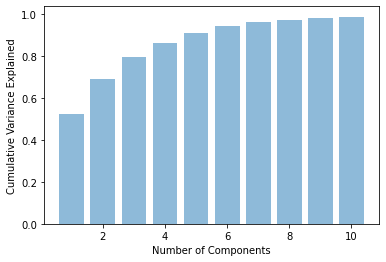

```python
plt.bar(list(range(1,11)),np.cumsum(pca.explained_variance_ratio_),alpha=0.5)
plt.ylabel('Cumulative Variance Explained')
plt.xlabel('Number of Components')
plt.show()
```

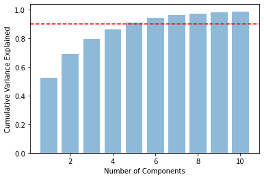

```python
plt.bar(list(range(1,11)),np.cumsum(pca.explained_variance_ratio_),alpha=0.5)
plt.axhline(y=0.9,color='red', linestyle ='dashed')
plt.ylabel('Cumulative Variance Explained')
plt.xlabel('Number of Components')
plt.show()
```

```python
pca = PCA(n_components=6)
xpca = pca.fit_transform(x)
```

```python
clf = svm.SVC(gamma=0.025, C=3)
clf.fit(xpca , y)
```

```
SVC(C=3, gamma=0.025)
```

```python
print('Accuracy with training dataset :')
print(metrics.accuracy_score(y, clf.predict(xpca)))
print('Evaluation matrics : ')
print(metrics.classification_report(y,clf.predict(xpca)))
```

```
Accuracy with training dataset :
0.8900709219858156
Evaluation matrics :
              precision    recall  f1-score   support

         bus       0.89      0.86      0.88       218
         car       0.90      0.92      0.91       429
         van       0.86      0.87      0.86       199

    accuracy                           0.89       846
   macro avg       0.89      0.88      0.88       846
weighted avg       0.89      0.89      0.89       846
```

Looks like by drop reducing dimensionality by 6, the accuracy has been decreased. This is insample (on training data) and hence a drop in accuracy is expected. Still seems easy to justify the dropping of variables. An out of sample (on test data), with the 6 independent variables is likely to do better since that would be less of an over-fit.